# Регрессионный анализ для бинарных данных

## Мы рассмотрим

- Регрессионный анализ для бинарных зависимых переменных

### Вы сможете

- Построить логистическую регрессионную модель, подобранную методом максимального правдоподобия
- Дать трактовку параметрам логистической регрессионной модели
- Провести анализ девиансы, основанный на логистической регрессии

## Бинарные данные - очень распространенный тип зависимых переменных

- Вид есть - вида нет
- Кто-то в результате эксперимента выжил или умер
- Пойманное животное заражено паразитами или здорово
- Команда выиграла или проиграла

и т.д.

## На каком острове лучше искать ящериц?

[figure not shown]

Пример взят из книги Quinn & Keugh (2002), Оригинальная работа Polis et al. (1998)

```
##     X.ISLAND PARATIO UTA PA PREDICT
## 1       Bota   15.41   P  1   0.555
## 2     Cabeza    5.63   P  1   0.915
## 3    Cerraja   25.92   P  1   0.111
## 4 Coronadito   15.17   A  0   0.568
## 5     Flecha   13.04   P  1   0.678
## 6   Gemelose   18.85   A  0   0.370
```

## Зависит ли встречаемость ящериц от размера острова?

Обычную линейную регрессию подобрать можно,

*Зависимая переменная*: PA - (есть ящерицы "1" - нет ящериц "0")  
*Предиктор* - PARATIO (отношение периметра к площади)

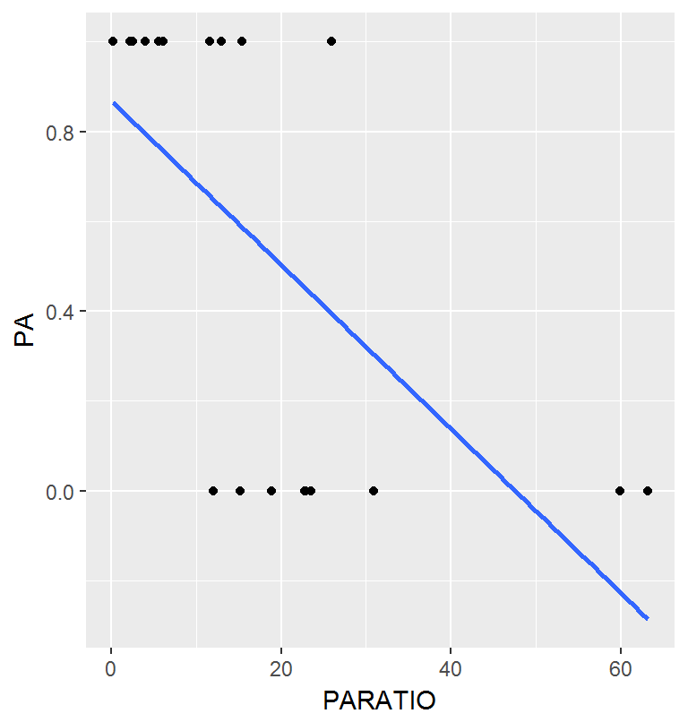

```
##
## Call:
## lm(formula = PA ~ PARATIO, data = liz)
##
## Residuals:
##    Min     1Q Median     3Q    Max
## -0.649 -0.445  0.178  0.264  0.605
##
## Coefficients:
##             Estimate Std. Error t value Pr(>|t|)
## (Intercept)  0.86881    0.14088    6.17  0.00001 ***
## PARATIO     -0.01828    0.00557   -3.28   0.0044 **
## ---
## Signif. codes:  0 '***' 0.001 '**' 0.01 '*' 0.05 '.' 0.1 ' ' 1
##
## Residual standard error: 0.413 on 17 degrees of freedom
## Multiple R-squared:  0.388,  Adjusted R-squared:  0.352
## F-statistic: 10.8 on 1 and 17 DF,  p-value: 0.00438
```

**но она категорически не годится**

## Эти данные лучше описывает логистическая кривая

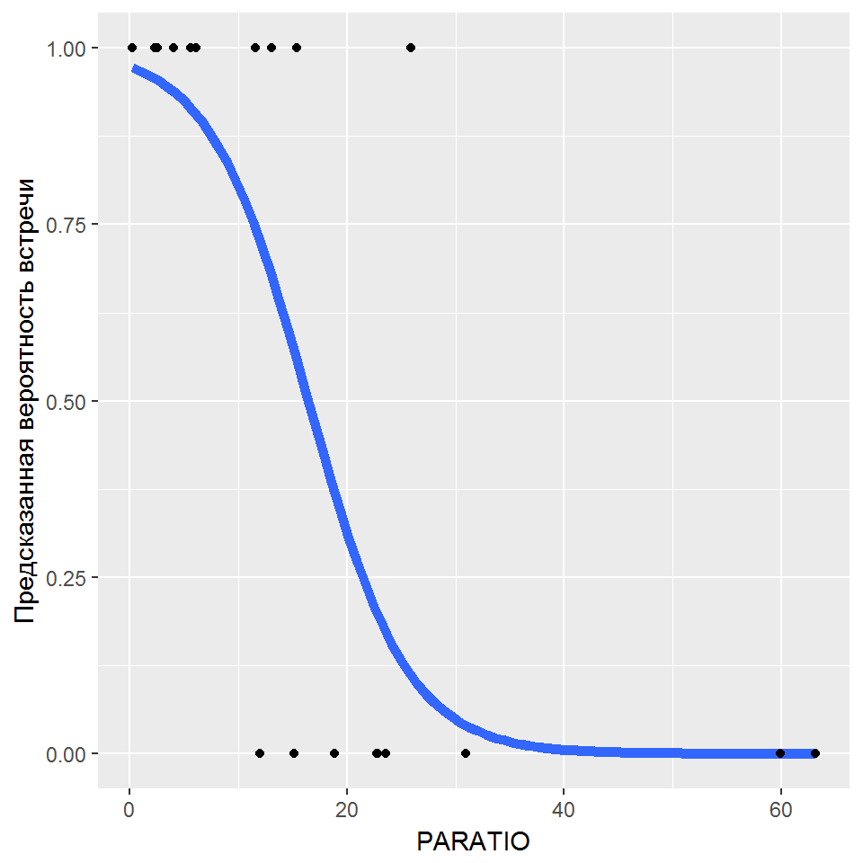

Логистическая кривая описывается такой формулой

\[ \pi(x) = \frac{e^{\beta_0+\beta_1x}}{1+e^{\beta_0+\beta_1x}} \]

## Зависимую величину можно преобразовать в более удобную для моделирования форму

1. Дискретный результат: 1 или 0
2. Дискретные данные можно преобразовать в форму оценки вероятности события: \(\pi = \frac{N_i}{N_{total}}\), непрерывная величина, варьирующая от 0 до 1
3. Вероятность события можно выразить в форме шансов (odds): \(odds=\frac{\pi}{1-\pi}\) варьируют от 0 до \(+\infty\). *NB: Если шансы > 1, то вероятность события, что \(y_i=1\) выше, чем вероятность события \(y_i = 0\). Если шансы < 1, то наоборот*. В обыденной речи мы часто использем фразы, наподобие такой "*шансы на победу 1 к 3*"
4. Шансы преобразуются в *Логиты* (logit): \(ln(odds)=\ln(\frac{\pi}{1-\pi})\) варьируют от \(-\infty\) до \(+\infty\). Логиты гораздо удобнее для построения моделей.

## Логистическая модель после логит-преобразования становится привычной линейной моделью!

### Немного алгебры

Обозначим для краткости \(\beta_0 + \beta_1x \equiv z\)

Тогда, логистическая модель примет такую форму \[ g(x)=\ln(\frac{\pi(x)}{1-\pi(x)})= \ln(\frac{\frac{e^z}{1+e^z}}{1-\frac{e^z}{1+e^z}}) \]

## Немного алгебры

Из курса алгебры мы помним, что логарифм отношения равен разности логарифмов \[ g(x)=\ln(\frac{e^z}{1+e^z}) - \ln({1-\frac{e^z}{1+e^z}}) \]

Тогда…

- \[ g(x)=\ln(\frac{e^z}{1+e^z}) - \ln({\frac{1+e^z - e^z}{1+e^z}}) = \ln(\frac{e^z}{1+e^z}) - \ln({\frac{1}{1+e^z}}) \]
- \[ g(x)=\ln(e^z) - \ln(1+e^z) - (\ln(1) -\ln(1+e^z)) \]
- \[ g(x)=\ln(e^z) - \ln(1+e^z) - 0 +\ln(1+e^z) = \ln(e^z) = z \]

## Логистическая модель после логит-преобразования становится линейной

\[ g(x)=\ln(\frac{\pi(x)}{1-\pi(x)})=\beta_0 + \beta_1x\]

Остается только подобрать параметры этой линейной модели: \(\beta_0\) (интерсепт) и \(\beta_1\) (угловой коэффициент)

## Метод максимального правдоподобия

### Вспомним

Если остатки не подчиняется нормальному распределению, то метод наименьших квадратов не работает.  
В этом случае применяют *Метод максимального правдоподбия*

В результате итеративных процедур происходит подбор таких значений коэффициентов, при которых правдоподобие - вероятность получения имеющегося у нас набора данных - оказывается максимальным, при условии справедливости данной модели.

\[ Lik(x_1, ..., x_n) = \Pi^n _{i = 1}f(x_i; \theta)\]

где \(f(x; \theta)\) - функция плотности вероятности с параметрами \(\theta\)

## Кратко о методе макcимального правдоподобия

## Правдоподобие для нормального распределения

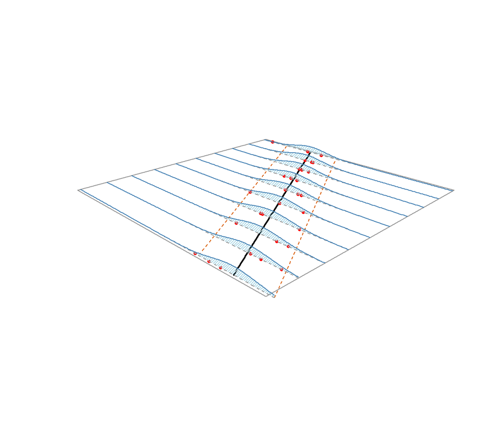

Симулированный пример, в котором

\[ y_i = 10x_i + \varepsilon_i \\ \varepsilon \in N(0, 15) \]

Точки (данные) - это выборки из нескольких "локальных" генеральных совокупностей с нормальным распределением зависимой переменной (каждая совокупность соответствует одному значению предиктора).

Линия регрессии проходит через средние значения нормальных распределений.

Параметры прямой подбираются так, чтобы вероятность существования данных при таких параметрах была бы максимальной.

## Правдоподобие для нормального распределения

Аналогичная картинка, но с использованием `geom_violin()`

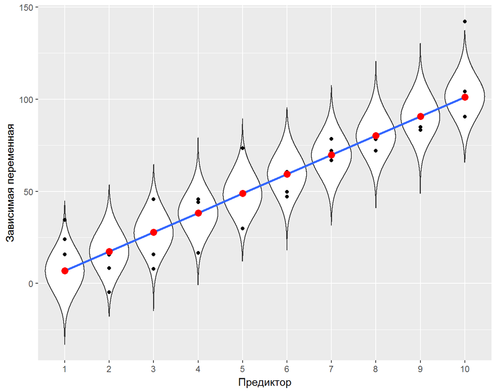

## Нормальное распределение

То, что мы в быту привыкли называть **распределением** - это функция плотности вероятности.

**Плотность вероятности** - это функция, описывающая вероятность получения разных значений случайной величины

## Нормальное распределение

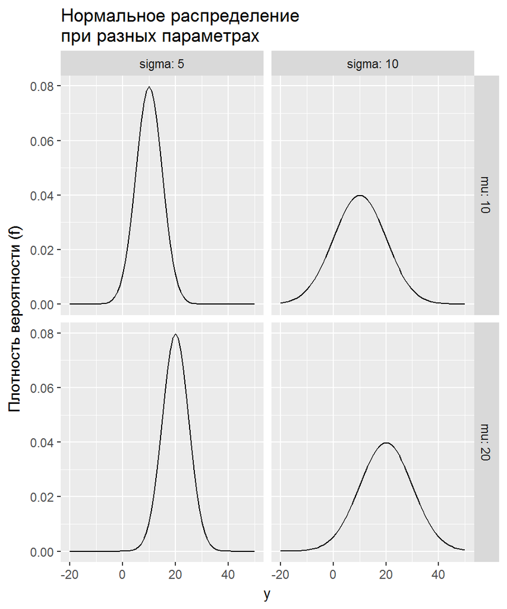

\[f(y;\mu, \sigma)= \frac {1}{\sigma \sqrt{2 \pi}} e^{-\frac{(y-\mu)^2}{2\sigma^2}}\]

### Два параметра (\(\mu\), \(\sigma\))

Среднее: \(E(Y) = \mu\)

Дисперсия: \(var(Y) = \sigma^2\)

### Пределы варьирования

\(-\infty \le Y \le +\infty\)

## Биномиальное распределение

\(f(y; N, \pi) = \frac{N!}{y! \times (N-y)!} \times \pi^y \times (1 - \pi)^{N-y}\)

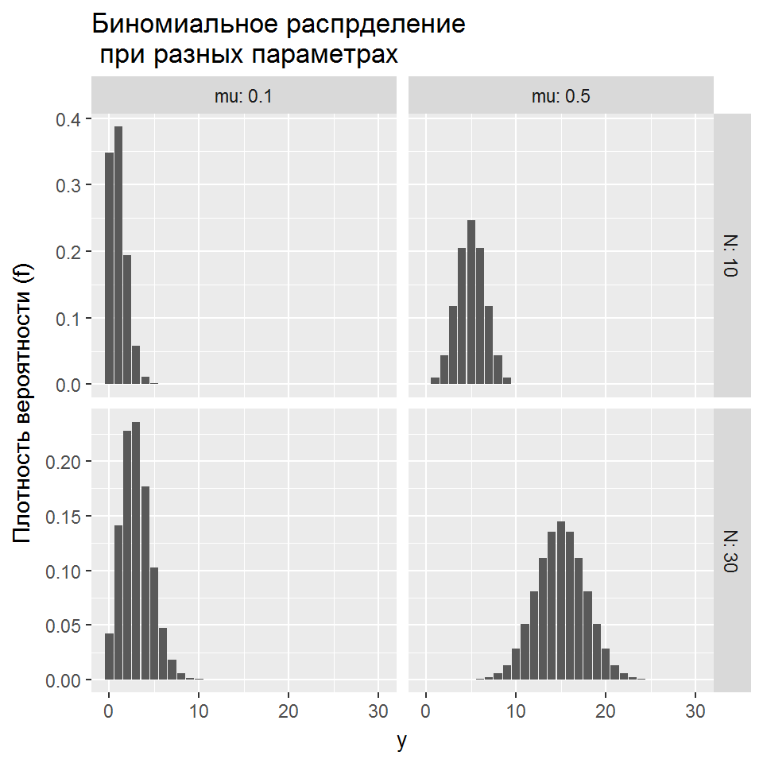

### Два параметра (\(N\), \(\pi\))

Среднее: \(E(Y) = N \times \pi\)  
Дисперсия: \(var(Y) = N \times \pi \times (1-\pi)\)  
Параметр \(N\) определяет количество объектов в испытании  
Параметр \(\pi\) - вероятность события (\(y = 1\))

### Пределы варьирования

\(0 \le Y \le +\infty\), \(Y\) **целочисленные**

## Правдоподобие для биномиального распределения

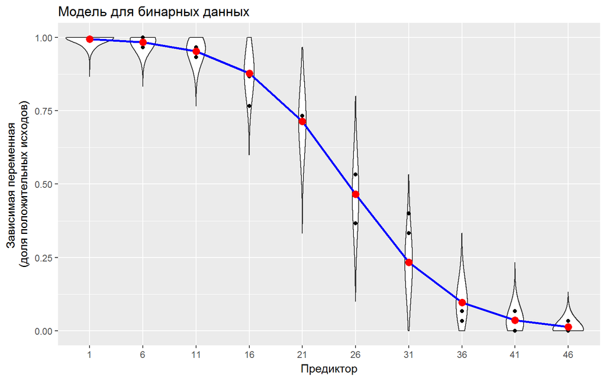

## Функция правдоподобия для биномиального распределения

Для случая биномиального распределения \(x \in Bin(n, \pi)\) функция правдоподобия имеет следующий вид:

\[Lik(\pi|x) = \frac{n!}{(n-x)!x!}\pi^x(1-\pi)^{n-x}\]

отбросив константу, получаем:

\[Lik(\pi|x) \propto \pi^x(1-\pi)^{n-x}\]

### Логарифм правдоподобия

Удобнее работать с логарифмом функции правдоподобия - \(logLik\) - его легче максимизировать. В случае биномиального распределения он выглядит так:

\[logLik(\pi|x) = x log(\pi) + (n-x)log(1-\pi)\]

## Подберем модель

```r
liz_model <- glm(PA ~ PARATIO , family="binomial", data = liz)
summary(liz_model)
```

```
##
## Call:
## glm(formula = PA ~ PARATIO, family = "binomial", data = liz)
##
## Deviance Residuals:
##    Min      1Q  Median      3Q     Max
## -1.607  -0.638   0.237   0.433   2.099
##
## Coefficients:
##             Estimate Std. Error z value Pr(>|z|)
## (Intercept)    3.606      1.695    2.13    0.033 *
## PARATIO       -0.220      0.101   -2.18    0.029 *
## ---
## Signif. codes:  0 '***' 0.001 '**' 0.01 '*' 0.05 '.' 0.1 ' ' 1
##
## (Dispersion parameter for binomial family taken to be 1)
##
##     Null deviance: 26.287  on 18  degrees of freedom
## Residual deviance: 14.221  on 17  degrees of freedom
## AIC: 18.22
##
## Number of Fisher Scoring iterations: 6
```

### `summary()` для модели, подобранной методом максимального правдоподобия

```
##
## Call:
## glm(formula = PA ~ PARATIO, family = "binomial", data = liz)
##
## Deviance Residuals:
##    Min      1Q  Median      3Q     Max
## -1.607  -0.638   0.237   0.433   2.099
##
## Coefficients:
##             Estimate Std. Error z value Pr(>|z|)
## (Intercept)    3.606      1.695    2.13    0.033 *
## PARATIO       -0.220      0.101   -2.18    0.029 *
## ---
## Signif. codes:  0 '***' 0.001 '**' 0.01 '*' 0.05 '.' 0.1 ' ' 1
##
## (Dispersion parameter for binomial family taken to be 1)
##
##     Null deviance: 26.287  on 18  degrees of freedom
## Residual deviance: 14.221  on 17  degrees of freedom
## AIC: 18.22
##
## Number of Fisher Scoring iterations: 6
```

Есть уже знакомые термины: `Estimate`, `Std. Error`, `AIC`  
Появились новые термины: `z value`, `Pr(>|z|)`, `Null deviance`, `Residual deviance`

## "z value"" и "Pr(>z)"

z - это величина критерия Вальда (*Wald statistic*) - аналог t-критерия

Используется для проверки \(H_0: \beta_1=0\)

\[z=\frac{\beta_1}{SE_{\beta_1}}\]

Сравнивают со стандартным нормальным распределением (z-распределение)

Дает надежные оценки p-value при больших выборках

## Null deviance и Residual deviance

Имеющиеся данные позволяют "вписать" три типа моделей

**"Насыщенная" модель** - модель, подразумевающая, что каждая из n точек имеет свой собственный параметр, следовательно надо подобрать n параметров. Вероятность существования данных для такой модели равна 1. \[logLik_{satur}=0\] \[df_{saturated} = n - npar_{saturated} = n - n = 0\]

**"Нулевая" модель** - модель, подразумевающая, что для описания всех точек надо подобрать только 1 параметр. \(g(x) = \beta_0\). \[logLik_{nul} \ne 0\] \[df_{null} = n - npar_{null} = n - 1\]

**"Предложенная" модель** - модель, подобранная в нашем анализе \(g(x) = \beta_0 + \beta_1x\) \[logLik_{prop} \ne 0\] \[df_{proposed} = n - npar_{proposed}\]

## Null deviance и Residual deviance

**Девианса** - это оценка отклонения логарифма максимального правдоподобия одной модели от логарифма максимального правдоподобия другой модели

**Остаточная девианса**:  
\(Dev_{resid} = 2(logLik_{satur} - logLik_{prop})=-2logLik_{prop}\)

**Нулевая девианса**:  
\(Dev_{nul} = 2(logLik_{satur} - logLik_{nul})=-2logLik_{nul}\)

Проверим, совпадут ли со значениями из `summary()`

```r
(Dev_resid <- -2*as.numeric(logLik(liz_model))) #Остаточная девианса
```

```
## [1] 14.2
```

```r
(Dev_nul <- -2*as.numeric(logLik(update(liz_model, ~-PARATIO)))) #Нулевая девианса
```

```
## [1] 26.3
```

## Анализ девиансы

**По соотношению нулевой девиансы и остаточной девиансы можно понять насколько статистически значима модель**

В основе анализа девиансы лежит критерий \(G^2\)

\[ G^2 = Dev_{nul} - Dev_{resid} = -2(logLik_{nul} - logLik_{prop})\]

```r
(G2 <- Dev_nul - Dev_resid)
```

```
## [1] 12.1
```

Вспомним тест отношения правдоподобий: \[ LRT = 2ln(Lik_1/Lik_2) = 2(logLik_1 - logLlik_2)\]

> Тест \(G^2\) - это частный случай теста отношения правдоподобий (Likelihood Ratio Test)

## Свойства критерия \(G^2\)

- \(G^2\) - это девианса полной (предложенной) и редуцированной модели (нулевой)
- \(G^2\) - аналог частного F критерия в обычном регрессионном анализе
- \(G^2\) - подчиняется \(\chi^2\) распределению если нулевая модель и предложенная модель не отличаются друг от друга. Параметр df - разница числа параметров предложенной и нулевой моделей.
- \(G^2\) можно использовать для проверки гипотезы о равенстве нулевой и остаточной девианс.

## Задание

1. Вычислите вручную значение критерия \(G^2\) для модели, описывающей встречаемость ящериц (`liz_model`)
2. Оцените уровень значимости для него

\[ G^2 = -2(logLik_{nul} - logLik_{prop})\]

## Решение

```r
#Остаточная девианса
Dev_resid <- -2*as.numeric(logLik(liz_model))

#Нулевая девианса
Dev_nul <- -2*as.numeric(logLik(update(liz_model, ~-PARATIO)))

# Значение критерия
(G2 <- Dev_nul - Dev_resid)
```

```
## [1] 12.1
```

```r
(p_value <- 1 - pchisq(G2, df = 1))
```

```
## [1] 0.000513
```

## Решение с помощью функции `Anova()`

```r
library(car)
Anova(liz_model)
```

```
## Analysis of Deviance Table (Type II tests)
##
## Response: PA
##         LR Chisq Df Pr(>Chisq)
## PARATIO     12.1  1    0.00051 ***
## ---
## Signif. codes:  0 '***' 0.001 '**' 0.01 '*' 0.05 '.' 0.1 ' ' 1
```

## Интерпретация коэффициентов логистической регрессии

## Как трактовать коэффициенты подобранной модели?

\[ g(x)=\ln(\frac{\pi(x)}{1-\pi(x)})=\beta_0 + \beta_1x\]

```r
coef(liz_model)
```

```
## (Intercept)     PARATIO
##        3.61       -0.22
```

\(\beta_0\) - не имеет особого смысла, просто поправочный коэффициент

\(\beta_1\) - *на сколько* единиц изменяется логарифм величины шансов (odds), если значение предиктора изменяется на единицу

Трактовать такую величину неудобно и трудно

## Немного алгебры

посмотрим как изменится \(g(x)=\ln(\frac{\pi(x)}{1-\pi(x)})\) при изменении предиктора на 1

\[g(x+1) - g(x) = ln(odds_{x+1}) - ln(odds_x) = ln(\frac{odds_{x+1}}{odds_x})\]

Задание: завершите алгебраическое преобразование

## Решение

\[ln(\frac{odds_{x+1}}{odds_x}) = \beta_0 + \beta_1(x+1) - \beta_0 - \beta_1x = \beta_1\]

\[ln(\frac{odds_{x+1}}{odds_x}) = \beta_1\]

\[\frac{odds_{x+1}}{odds_x} = e^{\beta_1}\]

## Полученная величина имеет определенный смысл

```r
exp(coef(liz_model)[2])
```

```
## PARATIO
##   0.803
```

*Во сколько* раз изменяются шансы встретить ящерицу при увеличении отношения периметра острова к его площади на одну единицу. *NB: Отношение периметра к площади тем больше, чем меньше остров*.

Шансы изменяются в 0.803 раза. То есть, чем больше отношение периметра к площади, тем меньше шансов встретить ящерицу. Значит, чем больше остров, тем больше шансов встретить ящерицу

## Подобранные коэффициенты позволяют построить логистическую кривую

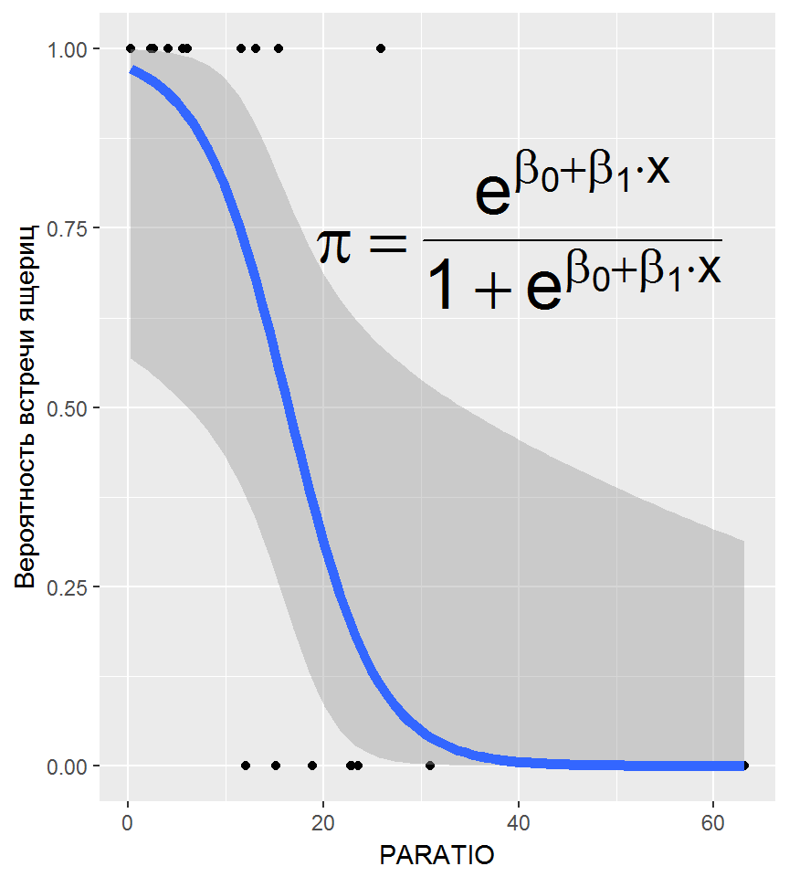

Серая область - доверительный интервал для логистической регрессии

Доверительные интервалы для коэффициентов:

```r
confint(liz_model) # для логитов
```

```
##              2.5 %  97.5 %
## (Intercept)  1.006  8.0421
## PARATIO     -0.485 -0.0665
```

```r
exp(confint(liz_model)) # для отношения шансов
```

```
##             2.5 %   97.5 %
## (Intercept) 2.734 3109.275
## PARATIO     0.616    0.936
```

## Задание:

Постройте график логистической регрессии для модели `liz_model` без использования `geom_smooth()`

Hint 1: Используйте функцию `predict()`, изучите значения параметра "type"

Hint 2: Для вызова справки напишите `predict.glm()`

Hint 3: Создайте датафрейм MyData с переменной `PARATIO`, изменяющейся от минимального до максимального значения `PARATIO`

## Решение

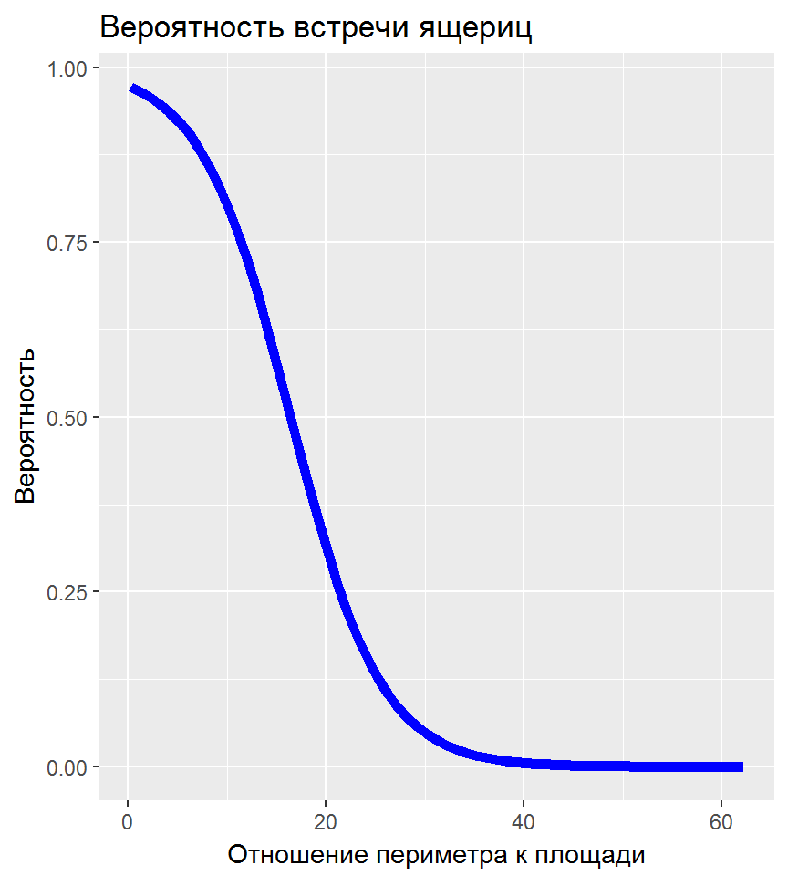

```r
MyData <- data.frame(PARATIO =
        seq(min(liz$PARATIO), max(liz$PARATIO)))

MyData$Predicted <- predict(liz_model,
                            newdata = MyData,
                            type = "response")

ggplot(MyData, aes(x = PARATIO, y = Predicted)) +
  geom_line(size=2, color = "blue") +
  xlab("Отношение периметра к площади") +
  ylab ("Вероятность") +
  ggtitle("Вероятность встречи ящериц")
```

## Применим матричную алгебру для вычисления предсказанных значений и доверительного интервала для линии регрессии

```r
# Создаем искуственный набор данных
MyData <- data.frame(PARATIO = seq(min(liz$PARATIO), max(liz$PARATIO)))

# Формируем модельную матрицу для искуственно созданных данных
X <- model.matrix( ~ PARATIO, data = MyData)
```

## Извлекаем характеристики подобранной модели и получаем предсказанные значения

```r
# Вычисляем параметры подобранной модели и ее матрицу ковариаций
betas    <- coef(liz_model) # Векор коэффицентов
Covbetas <- vcov(liz_model) # Ковариационная матрица

# Вычисляем предсказанные значения, перемножая модельную матрицу на вектор
# коэффициентов
MyData$eta <- X %*% betas
```

## Получаем предсказанные значения

```r
# Переводим предсказанные значения из логитов в вероятности
MyData$Pi  <- exp(MyData$eta) / (1 + exp(MyData$eta))
```

## Вычисляем границы доверительного интервала

```r
# Вычисляем стандартные отшибки путем перемножения матриц
  MyData$se <- sqrt(diag(X %*% Covbetas %*% t(X)))

# Вычисляем доверительные интервалы
MyData$CiUp  <- exp(MyData$eta + 1.96 *MyData$se) /
  (1 + exp(MyData$eta  + 1.96 *MyData$se))

MyData$CiLow  <- exp(MyData$eta - 1.96 *MyData$se) /
  (1 + exp(MyData$eta  - 1.96 *MyData$se))
```

## Строим график

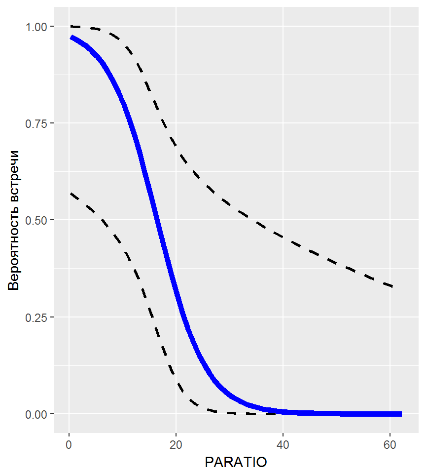

```r
ggplot(MyData, aes(x = PARATIO, y = Pi)) +
  geom_line(aes(x = PARATIO, y = CiUp),
            linetype = 2, size = 1) +
  geom_line(aes(x = PARATIO, y = CiLow),
            linetype = 2, size = 1) +
  geom_line(color = "blue", size=2) +
  ylab("Вероятность встречи")
```

## Диагностика модели

## Проблема избыточности дисперсии (overdispersion)

Если данные подчиняются биномиальному распределению, то Среднее: \(E(Y) = N \times \pi\)  
Дисперсия: \(var(Y) = N \times \pi \times (1-\pi)\)

То есть, дисперсия связана со средним. Если это нарушается, то мы не можем доверять результатам, так как модель, основанная на биномиальном распределении, применяется к данным, которые не подчиняются этому распределению.

## Проблема избыточности дисперсии (overdispersion)

Причины изботочности дисперсии

- При одном и том же значении предиктора вероятности событий не одинаковы (not identically distributed)
- События зависимы друг от друга (события при одном значении предиктора зависят от событий при другом зачении предиктора)

## Проверка на избыточность дисперсии

Пирсоновские остатки \(E_i = \frac{\varepsilon_i}{\sqrt{Var(\hat{y_i})}}\)

```r
E <- resid(liz_model, type = "pearson") #Пирсоновские остатки
p <- length(coef(liz_model)) #число параметров в модели
df <-   nrow(model.frame(liz_model)) - p #число степеней свободы
Overdisp <- sum(E^2) / df

Overdisp
```

```
## [1] 0.902
```

Здесь проблем нет!

Как поступать в случае присутствия избфточности дисперсии будет отдельный разговор.

## Есть ли паттерн в остатках?

В случае бинарных переменных появляется некоторая проблема…

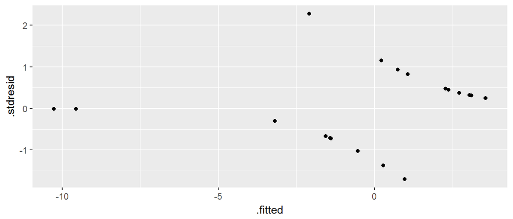

```r
library(ggplot2)
liz_mod_diagn <- fortify(liz_model)
ggplot(liz_mod_diagn, aes(x = .fitted, y = .stdresid)) + geom_point()
```

## Есть ли паттерн в остатках?

Для оценки присутствия паттерна надо разделить все .fitted на группы и посчитать среденее значение остатков

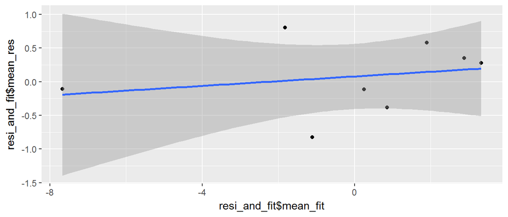

```r
library(dplyr)
liz_mod_diagn$group <- ntile(liz_mod_diagn$.fitted, 8)

resi_and_fit <- liz_mod_diagn %>%  group_by(group) %>%  summarise(mean_fit = mean(.fitted), mean_res = mean(.stdresid))

qplot(resi_and_fit$mean_fit, resi_and_fit$mean_res ) + geom_smooth(method = "lm")
```

## Множественная логистическая регрессия

## От чего зависит уровень смертности пациентов, выписанных из реанимации?

Данные, полученные на основе изучения 200 историй болезни пациентов одного из американских госпиталей

- STA: Статус (0 = Выжил, 1 = умер)
- AGE: Возраст
- SEX: Пол
- RACE: Раса
- SER: Тип мероприятий в реанимации (0 = Medical, 1 = Surgical)
- CAN: Присутствует ли онкология? (0 = No, 1 = Yes)
- CRN: Присутствует ли почечная недостаточность (0 = No, 1 = Yes)
- INF: Возможность инфекции (0 = No, 1 = Yes)
- CPR: CPR prior to ICU admission (0 = No, 1 = Yes)
- SYS: Давление во время поступления в реанимацию (in mm Hg)
- HRA: Пульс (beats/min)
- PRE: Была ли госпитализация в предыдущие 6 месяцев (0 = No, 1 = Yes)
- TYP: Тип госпитализации (0 = Elective, 1 = Emergency)
- FRA: Присутствие переломов (0 = No, 1 = Yes)
- PO2: Концентрация кислорода в крови (0 = >60, 1 = ²60)
- PH: Уровень кислотности крови (0 = ³7.25, 1 < 7.25)
- PCO: Концентрация углекислого газа в крови (0 = ²45, 1 = > 45)
- BIC: Bicarbonate from initial blood gases (0 = ³18, 1 = < 18)
- CRE: Уровень креатина (0 = ²2.0, 1 = > 2.0)
- LOC: Уровень сознания пациента при реанимации (0 = no coma or stupor, 1= deep stupor, 2 = coma)

## Смотрим на данные

```r
surviv <- read.table("data/ICU.csv", header=TRUE, sep=";")
head(surviv)
```

```
##   STA AGE    SEX   RAC      SER CAN CRN INF CPR SYS HRA PRE       TYP
## 1   0  27 Female White  Medical  No  No Yes  No 142  88  No Emergency
## 2   0  59   Male White  Medical  No  No  No  No 112  80 Yes Emergency
## 3   0  77   Male White Surgical  No  No  No  No 100  70  No  Elective
## 4   0  54   Male White  Medical  No  No Yes  No 142 103  No Emergency
## 5   0  87 Female White Surgical  No  No Yes  No 110 154 Yes Emergency
## 6   0  69   Male White  Medical  No  No Yes  No 110 132  No Emergency
##   FRA PO2 PH PCO BIC CRE LOC
## 1  No   1  1   1   1   1   1
## 2  No   1  1   1   1   1   1
## 3  No   1  1   1   1   1   1
## 4 Yes   1  1   1   1   1   1
## 5  No   1  1   1   1   1   1
## 6  No   2  1   1   2   1   1
```

## Сделаем факторами те дискретные предикторы, которые обозначенны цифрами

```r
surviv$PO2 <- factor(surviv$PO2)
surviv$PH <- factor(surviv$PH)
surviv$PCO <- factor(surviv$PCO)
surviv$BIC <- factor(surviv$BIC)
surviv$CRE <- factor(surviv$CRE)
surviv$LOC <- factor(surviv$LOC)
```

## Строим модель

```r
M1 <- glm(STA ~ ., family = "binomial", data = surviv)
summary(M1)
```

```
##
## Call:
## glm(formula = STA ~ ., family = "binomial", data = surviv)
##
## Deviance Residuals:
##     Min       1Q   Median       3Q      Max
## -1.5052  -0.5372  -0.1787  -0.0002   3.0171
##
## Coefficients:
##                Estimate Std. Error z value Pr(>|z|)
## (Intercept)   -22.44426 1314.00889   -0.02   0.9864
## AGE             0.05645    0.01848    3.05   0.0023 **
## SEXMale         0.72146    0.54600    1.32   0.1864
## RACOther       16.75746 1314.00721    0.01   0.9898
## RACWhite       16.17455 1314.00665    0.01   0.9902
## SERSurgical    -0.67386    0.62894   -1.07   0.2840
## CANYes          3.48260    1.12114    3.11   0.0019 **
## CRNYes          0.11914    0.84488    0.14   0.8879
## INFYes         -0.10812    0.55570   -0.19   0.8457
## CPRYes          1.03223    0.99008    1.04   0.2971
## SYS            -0.02084    0.00944   -2.21   0.0273 *
## HRA            -0.00292    0.01032   -0.28   0.7776
## PREYes          1.27950    0.70215    1.82   0.0684 .
## TYPEmergency    3.74788    1.34222    2.79   0.0052 **
## FRAYes          1.64945    1.09334    1.51   0.1314
## PO22           -0.67651    0.94017   -0.72   0.4718
## PH2             1.77098    1.21243    1.46   0.1441
## PCO2           -2.08358    1.16463   -1.79   0.0736 .
## BIC2           -0.26235    0.89668   -0.29   0.7698
## CRE2            0.10040    1.13073    0.09   0.9292
## LOC2           37.70527 2486.66692    0.02   0.9879
## LOC3            3.45837    1.34154    2.58   0.0099 **
## ---
## Signif. codes:  0 '***' 0.001 '**' 0.01 '*' 0.05 '.' 0.1 ' ' 1
##
## (Dispersion parameter for binomial family taken to be 1)
##
##     Null deviance: 200.16  on 199  degrees of freedom
## Residual deviance: 112.17  on 178  degrees of freedom
## AIC: 156.2
##
## Number of Fisher Scoring iterations: 17
```

## Задание

Проведите анализ девиансы для данной модели

## Решение

```r
Anova(M1)
```

```
## Analysis of Deviance Table (Type II tests)
##
## Response: STA
##     LR Chisq Df   Pr(>Chisq)
## AGE     12.3  1      0.00045 ***
## SEX      1.8  1      0.17680
## RAC      3.6  2      0.16709
## SER      1.2  1      0.27931
## CAN     10.8  1      0.00104 **
## CRN      0.0  1      0.88815
## INF      0.0  1      0.84555
## CPR      1.1  1      0.30207
## SYS      5.8  1      0.01573 *
## HRA      0.1  1      0.77674
## PRE      3.2  1      0.07194 .
## TYP     13.1  1      0.00030 ***
## FRA      2.1  1      0.14943
## PO2      0.5  1      0.46604
## PH       2.2  1      0.13641
## PCO      3.7  1      0.05363 .
## BIC      0.1  1      0.76849
## CRE      0.0  1      0.92931
## LOC     39.0  2 0.0000000034 ***
## ---
## Signif. codes:  0 '***' 0.001 '**' 0.01 '*' 0.05 '.' 0.1 ' ' 1
```

## Задание

Подберите оптимальную модель в соответствии с протоколом обратного пошагового отбора

## Решение

```r
drop1(M1, test = "Chi")
```

```
## Single term deletions
##
## Model:
## STA ~ AGE + SEX + RAC + SER + CAN + CRN + INF + CPR + SYS + HRA +
##     PRE + TYP + FRA + PO2 + PH + PCO + BIC + CRE + LOC
##        Df Deviance AIC  LRT     Pr(>Chi)
## <none>         112 156
## AGE     1      124 166 12.3      0.00045 ***
## SEX     1      114 156  1.8      0.17680
## RAC     2      116 156  3.6      0.16709
## SER     1      113 155  1.2      0.27931
## CAN     1      123 165 10.8      0.00104 **
## CRN     1      112 154  0.0      0.88815
## INF     1      112 154  0.0      0.84555
## CPR     1      113 155  1.1      0.30207
## SYS     1      118 160  5.8      0.01573 *
## HRA     1      112 154  0.1      0.77674
## PRE     1      115 157  3.2      0.07194 .
## TYP     1      125 167 13.1      0.00030 ***
## FRA     1      114 156  2.1      0.14943
## PO2     1      113 155  0.5      0.46604
## PH      1      114 156  2.2      0.13641
## PCO     1      116 158  3.7      0.05363 .
## BIC     1      112 154  0.1      0.76849
## CRE     1      112 154  0.0      0.92931
## LOC     2      151 191 39.0 0.0000000034 ***
## ---
## Signif. codes:  0 '***' 0.001 '**' 0.01 '*' 0.05 '.' 0.1 ' ' 1
```

```r
M2 <- update(M1, .~.-CRE)
```

## Решение

```r
drop1(M2, test = "Chi")
```

```
## Single term deletions
##
## Model:
## STA ~ AGE + SEX + RAC + SER + CAN + CRN + INF + CPR + SYS + HRA +
##     PRE + TYP + FRA + PO2 + PH + PCO + BIC + LOC
##        Df Deviance AIC  LRT    Pr(>Chi)
## <none>         112 154
## AGE     1      125 165 12.9     0.00033 ***
## SEX     1      114 154  1.8     0.17771
## RAC     2      116 154  3.6     0.16382
## SER     1      113 153  1.2     0.27525
## CAN     1      123 163 11.1     0.00086 ***
## CRN     1      112 152  0.0     0.86526
## INF     1      112 152  0.0     0.83888
## CPR     1      113 153  1.1     0.30376
## SYS     1      118 158  6.0     0.01460 *
## HRA     1      112 152  0.1     0.78446
## PRE     1      115 155  3.3     0.07113 .
## TYP     1      125 165 13.1     0.00029 ***
## FRA     1      114 154  2.1     0.14705
## PO2     1      113 153  0.6     0.44166
## PH      1      114 154  2.3     0.12703
## PCO     1      116 156  3.9     0.04779 *
## BIC     1      112 152  0.1     0.77661
## LOC     2      151 189 39.2 0.000000003 ***
## ---
## Signif. codes:  0 '***' 0.001 '**' 0.01 '*' 0.05 '.' 0.1 ' ' 1
```

```r
M3 <- update(M2, .~.-CRN)
```

## Решение

```r
drop1(M3, test = "Chi")
```

```
## Single term deletions
##
## Model:
## STA ~ AGE + SEX + RAC + SER + CAN + INF + CPR + SYS + HRA + PRE +
##     TYP + FRA + PO2 + PH + PCO + BIC + LOC
##        Df Deviance AIC  LRT     Pr(>Chi)
## <none>         112 152
## AGE     1      126 164 13.3      0.00026 ***
## SEX     1      114 152  1.8      0.17474
## RAC     2      116 152  3.6      0.16506
## SER     1      114 152  1.3      0.26317
## CAN     1      124 162 11.3      0.00078 ***
## INF     1      112 150  0.0      0.85400
## CPR     1      113 151  1.1      0.30099
## SYS     1      118 156  6.0      0.01449 *
## HRA     1      112 150  0.1      0.77183
## PRE     1      116 154  3.4      0.06598 .
## TYP     1      126 164 13.3      0.00026 ***
## FRA     1      114 152  2.1      0.14736
## PO2     1      113 151  0.6      0.44493
## PH      1      115 153  2.8      0.09637 .
## PCO     1      116 154  4.2      0.04049 *
## BIC     1      112 150  0.1      0.78574
## LOC     2      152 188 39.6 0.0000000026 ***
## ---
## Signif. codes:  0 '***' 0.001 '**' 0.01 '*' 0.05 '.' 0.1 ' ' 1
```

```r
M4 <- update(M3, .~.-INF)
```

## Решение

```r
drop1(M4, test = "Chi")
```

```
## Single term deletions
##
## Model:
## STA ~ AGE + SEX + RAC + SER + CAN + CPR + SYS + HRA + PRE + TYP +
##     FRA + PO2 + PH + PCO + BIC + LOC
##        Df Deviance AIC  LRT     Pr(>Chi)
## <none>         112 150
## AGE     1      126 162 13.6      0.00023 ***
## SEX     1      114 150  1.8      0.17862
## RAC     2      116 150  3.6      0.16358
## SER     1      114 150  1.2      0.26408
## CAN     1      124 160 11.3      0.00079 ***
## CPR     1      113 149  1.0      0.30874
## SYS     1      118 154  6.1      0.01385 *
## HRA     1      112 148  0.1      0.74857
## PRE     1      116 152  3.4      0.06683 .
## TYP     1      126 162 13.3      0.00026 ***
## FRA     1      114 150  2.1      0.14845
## PO2     1      113 149  0.6      0.43994
## PH      1      115 151  2.7      0.09821 .
## PCO     1      116 152  4.2      0.04121 *
## BIC     1      112 148  0.1      0.77052
## LOC     2      152 186 39.7 0.0000000024 ***
## ---
## Signif. codes:  0 '***' 0.001 '**' 0.01 '*' 0.05 '.' 0.1 ' ' 1
```

```r
M5 <- update(M4, .~.-BIC)
```

## Решение

```r
drop1(M5, test = "Chi")
```

```
## Single term deletions
##
## Model:
## STA ~ AGE + SEX + RAC + SER + CAN + CPR + SYS + HRA + PRE + TYP +
##     FRA + PO2 + PH + PCO + LOC
##        Df Deviance AIC  LRT     Pr(>Chi)
## <none>         112 148
## AGE     1      126 160 13.5      0.00024 ***
## SEX     1      114 148  1.8      0.18306
## RAC     2      116 148  3.6      0.16241
## SER     1      114 148  1.2      0.28094
## CAN     1      124 158 11.5      0.00070 ***
## CPR     1      114 148  1.1      0.28822
## SYS     1      118 152  6.0      0.01453 *
## HRA     1      112 146  0.1      0.75785
## PRE     1      116 150  3.5      0.06035 .
## TYP     1      126 160 13.4      0.00025 ***
## FRA     1      114 148  2.2      0.14147
## PO2     1      113 147  0.7      0.40008
## PH      1      115 149  2.8      0.09422 .
## PCO     1      117 151  4.2      0.03958 *
## LOC     2      152 184 39.7 0.0000000024 ***
## ---
## Signif. codes:  0 '***' 0.001 '**' 0.01 '*' 0.05 '.' 0.1 ' ' 1
```

```r
M6 <- update(M5, .~.-PO2)
```

## Решение

```r
drop1(M6, test = "Chi")
```

```
## Single term deletions
##
## Model:
## STA ~ AGE + SEX + RAC + SER + CAN + CPR + SYS + HRA + PRE + TYP +
##     FRA + PH + PCO + LOC
##        Df Deviance AIC  LRT     Pr(>Chi)
## <none>         113 147
## AGE     1      126 158 12.8      0.00035 ***
## SEX     1      115 147  1.6      0.21163
## RAC     2      116 146  3.4      0.18624
## SER     1      114 146  0.8      0.36474
## CAN     1      124 156 10.9      0.00096 ***
## CPR     1      115 147  1.6      0.20124
## SYS     1      118 150  5.4      0.02062 *
## HRA     1      113 145  0.1      0.75012
## PRE     1      116 148  3.3      0.06833 .
## TYP     1      126 158 13.1      0.00029 ***
## FRA     1      115 147  1.8      0.17622
## PH      1      116 148  2.5      0.11193
## PCO     1      118 150  4.9      0.02654 *
## LOC     2      152 182 39.0 0.0000000034 ***
## ---
## Signif. codes:  0 '***' 0.001 '**' 0.01 '*' 0.05 '.' 0.1 ' ' 1
```

```r
M7 <- update(M6, .~.-HRA)
```

## Решение

```r
drop1(M7, test = "Chi")
```

```
## Single term deletions
##
## Model:
## STA ~ AGE + SEX + RAC + SER + CAN + CPR + SYS + PRE + TYP + FRA +
##     PH + PCO + LOC
##        Df Deviance AIC  LRT     Pr(>Chi)
## <none>         113 145
## AGE     1      126 156 12.7      0.00037 ***
## SEX     1      115 145  1.6      0.20532
## RAC     2      117 145  3.6      0.16528
## SER     1      114 144  0.7      0.39006
## CAN     1      124 154 10.9      0.00095 ***
## CPR     1      115 145  1.6      0.21134
## SYS     1      118 148  5.3      0.02171 *
## PRE     1      116 146  3.3      0.06806 .
## TYP     1      126 156 13.0      0.00030 ***
## FRA     1      115 145  1.9      0.16854
## PH      1      116 146  2.5      0.11142
## PCO     1      118 148  5.3      0.02099 *
## LOC     2      154 182 40.5 0.0000000016 ***
## ---
## Signif. codes:  0 '***' 0.001 '**' 0.01 '*' 0.05 '.' 0.1 ' ' 1
```

```r
M8 <- update(M7, .~.-SER)
```

## Решение

```r
drop1(M8, test = "Chi")
```

```
## Single term deletions
##
## Model:
## STA ~ AGE + SEX + RAC + CAN + CPR + SYS + PRE + TYP + FRA + PH +
##     PCO + LOC
##        Df Deviance AIC  LRT    Pr(>Chi)
## <none>         114 144
## AGE     1      127 155 12.7     0.00036 ***
## SEX     1      116 144  1.9     0.16807
## RAC     2      117 143  3.3     0.18869
## CAN     1      124 152 10.6     0.00112 **
## CPR     1      116 144  2.2     0.13891
## SYS     1      120 148  5.6     0.01770 *
## PRE     1      117 145  3.1     0.07900 .
## TYP     1      133 161 19.5 0.000010255 ***
## FRA     1      115 143  1.4     0.23904
## PH      1      117 145  2.8     0.09212 .
## PCO     1      119 147  5.1     0.02420 *
## LOC     2      154 180 40.0 0.000000002 ***
## ---
## Signif. codes:  0 '***' 0.001 '**' 0.01 '*' 0.05 '.' 0.1 ' ' 1
```

```r
M9 <- update(M8, .~.-FRA)
```

## Решение

```r
drop1(M9, test = "Chi")
```

```
## Single term deletions
##
## Model:
## STA ~ AGE + SEX + RAC + CAN + CPR + SYS + PRE + TYP + PH + PCO +
##     LOC
##        Df Deviance AIC  LRT     Pr(>Chi)
## <none>         115 143
## AGE     1      127 153 11.3      0.00076 ***
## SEX     1      117 143  1.7      0.19551
## RAC     2      118 142  3.2      0.20125
## CAN     1      125 151  9.7      0.00181 **
## CPR     1      117 143  1.8      0.17699
## SYS     1      121 147  5.9      0.01479 *
## PRE     1      118 144  2.6      0.10467
## TYP     1      135 161 19.3 0.0000111922 ***
## PH      1      118 144  2.9      0.08690 .
## PCO     1      120 146  4.6      0.03239 *
## LOC     2      154 178 39.1 0.0000000032 ***
## ---
## Signif. codes:  0 '***' 0.001 '**' 0.01 '*' 0.05 '.' 0.1 ' ' 1
```

```r
M10 <- update(M9, .~.-RAC)
```

## Решение

```r
drop1(M10, test = "Chi")
```

```
## Single term deletions
##
## Model:
## STA ~ AGE + SEX + CAN + CPR + SYS + PRE + TYP + PH + PCO + LOC
##        Df Deviance AIC  LRT     Pr(>Chi)
## <none>         118 142
## AGE     1      132 154 13.8       0.0002 ***
## SEX     1      120 142  1.7       0.1930
## CAN     1      129 151 10.3       0.0014 **
## CPR     1      120 142  1.7       0.1863
## SYS     1      125 147  6.2       0.0128 *
## PRE     1      120 142  2.1       0.1510
## TYP     1      138 160 19.8 0.0000085712 ***
## PH      1      122 144  3.3       0.0708 .
## PCO     1      123 145  4.7       0.0300 *
## LOC     2      156 176 37.1 0.0000000089 ***
## ---
## Signif. codes:  0 '***' 0.001 '**' 0.01 '*' 0.05 '.' 0.1 ' ' 1
```

```r
M11 <- update(M10, .~.-SEX)
```

## Решение

```r
drop1(M11, test = "Chi")
```

```
## Single term deletions
##
## Model:
## STA ~ AGE + CAN + CPR + SYS + PRE + TYP + PH + PCO + LOC
##        Df Deviance AIC  LRT    Pr(>Chi)
## <none>         120 142
## AGE     1      133 153 12.5      0.0004 ***
## CAN     1      129 149  9.1      0.0026 **
## CPR     1      122 142  1.5      0.2140
## SYS     1      127 147  7.0      0.0083 **
## PRE     1      122 142  1.9      0.1729
## TYP     1      139 159 18.4 0.000017917 ***
## PH      1      123 143  3.1      0.0798 .
## PCO     1      125 145  4.8      0.0292 *
## LOC     2      157 175 36.5 0.000000012 ***
## ---
## Signif. codes:  0 '***' 0.001 '**' 0.01 '*' 0.05 '.' 0.1 ' ' 1
```

```r
M12 <- update(M11, .~.-CPR)
```

## Решение

```r
drop1(M12, test = "Chi")
```

```
## Single term deletions
##
## Model:
## STA ~ AGE + CAN + SYS + PRE + TYP + PH + PCO + LOC
##        Df Deviance AIC  LRT     Pr(>Chi)
## <none>         122 142
## AGE     1      134 152 12.0      0.00054 ***
## CAN     1      131 149  9.3      0.00228 **
## SYS     1      128 146  6.7      0.00960 **
## PRE     1      123 141  1.6      0.20846
## TYP     1      141 159 19.7 0.0000092757 ***
## PH      1      125 143  3.5      0.06285 .
## PCO     1      126 144  4.3      0.03830 *
## LOC     2      162 178 39.9 0.0000000022 ***
## ---
## Signif. codes:  0 '***' 0.001 '**' 0.01 '*' 0.05 '.' 0.1 ' ' 1
```

```r
M13 <- update(M12, .~.-PRE)
```

## Решение

```r
drop1(M13, test = "Chi")
```

```
## Single term deletions
##
## Model:
## STA ~ AGE + CAN + SYS + TYP + PH + PCO + LOC
##        Df Deviance AIC  LRT     Pr(>Chi)
## <none>         123 141
## AGE     1      136 152 12.7      0.00036 ***
## CAN     1      132 148  8.5      0.00360 **
## SYS     1      130 146  6.6      0.01014 *
## TYP     1      142 158 18.9 0.0000138199 ***
## PH      1      127 143  3.3      0.06984 .
## PCO     1      128 144  4.3      0.03740 *
## LOC     2      162 176 38.8 0.0000000037 ***
## ---
## Signif. codes:  0 '***' 0.001 '**' 0.01 '*' 0.05 '.' 0.1 ' ' 1
```

```r
M14 <- update(M13, .~.-PH)
```

## Решение

```r
drop1(M14, test = "Chi")
```

```
## Single term deletions
##
## Model:
## STA ~ AGE + CAN + SYS + TYP + PCO + LOC
##        Df Deviance AIC  LRT    Pr(>Chi)
## <none>         127 143
## AGE     1      139 153 12.0     0.00054 ***
## CAN     1      135 149  8.3     0.00405 **
## SYS     1      133 147  6.6     0.01004 *
## TYP     1      147 161 20.5 0.000005960 ***
## PCO     1      128 142  1.9     0.17158
## LOC     2      163 175 36.3 0.000000013 ***
## ---
## Signif. codes:  0 '***' 0.001 '**' 0.01 '*' 0.05 '.' 0.1 ' ' 1
```

```r
M15 <- update(M14, .~.-PCO)
```

## Решение

```r
drop1(M15, test = "Chi")
```

```
## Single term deletions
##
## Model:
## STA ~ AGE + CAN + SYS + TYP + LOC
##        Df Deviance AIC  LRT    Pr(>Chi)
## <none>         128 142
## AGE     1      139 151 10.8      0.0010 **
## CAN     1      136 148  7.8      0.0051 **
## SYS     1      135 147  6.2      0.0131 *
## TYP     1      148 160 19.9 0.000008314 ***
## LOC     2      164 174 35.1 0.000000024 ***
## ---
## Signif. codes:  0 '***' 0.001 '**' 0.01 '*' 0.05 '.' 0.1 ' ' 1
```

## Рассмотрим финальную модель

M15 вложена в M1 следовательно их можно сравнить тестом отношения правдоподобий

```r
anova(M1, M15, test = "Chi")
```

```
## Analysis of Deviance Table
##
## Model 1: STA ~ AGE + SEX + RAC + SER + CAN + CRN + INF + CPR + SYS + HRA +
##     PRE + TYP + FRA + PO2 + PH + PCO + BIC + CRE + LOC
## Model 2: STA ~ AGE + CAN + SYS + TYP + LOC
##   Resid. Df Resid. Dev  Df Deviance Pr(>Chi)
## 1       178        112
## 2       193        128 -15    -16.3     0.36
```

## Диагностика модели

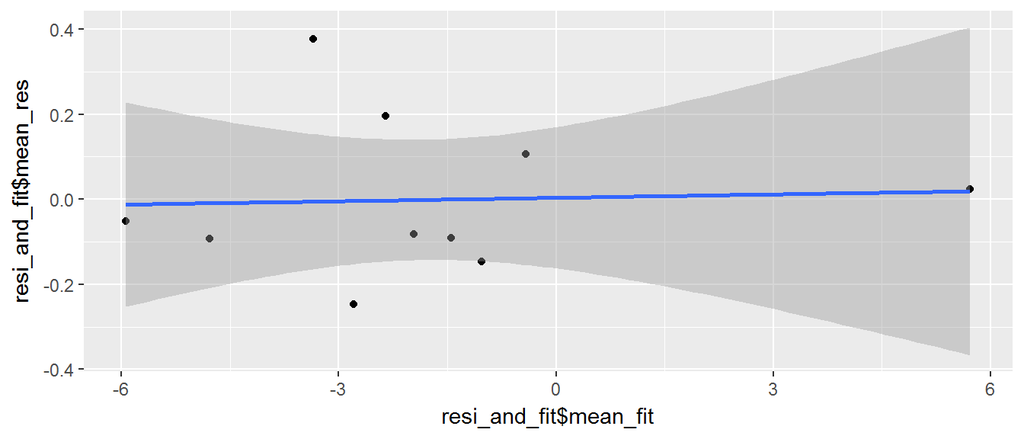

```r
M15_diag <- data.frame(.fitted = predict(M15),
    .pears_resid = residuals(M15, type = "pearson"))

M15_diag$group <- ntile(M15_diag$.fitted, 10)


resi_and_fit <- M15_diag %>%  group_by(group) %>%  summarise(mean_fit = mean(.fitted), mean_res = mean(.pears_resid))

qplot(resi_and_fit$mean_fit, resi_and_fit$mean_res ) + geom_smooth(method = "lm")
```

Явного паттерна в остатках нет

## Проверяем на избыточность дисперсии

```r
E <- resid(M15, type = "pearson") #Пирсоновские остатки
p <- length(coef(M15)) #число параметров в модели
df <-   nrow(model.frame(M15)) - p #число степеней свободы
Overdisp <- sum(E^2) / df

Overdisp
```

```
## [1] 0.931
```

Признаков избыточности дисперсии нет!

## Решение

```r
exp(coef(M15)[3])
```

```
## CANYes
##   13.4
```

## Визуализируем предсказания модели

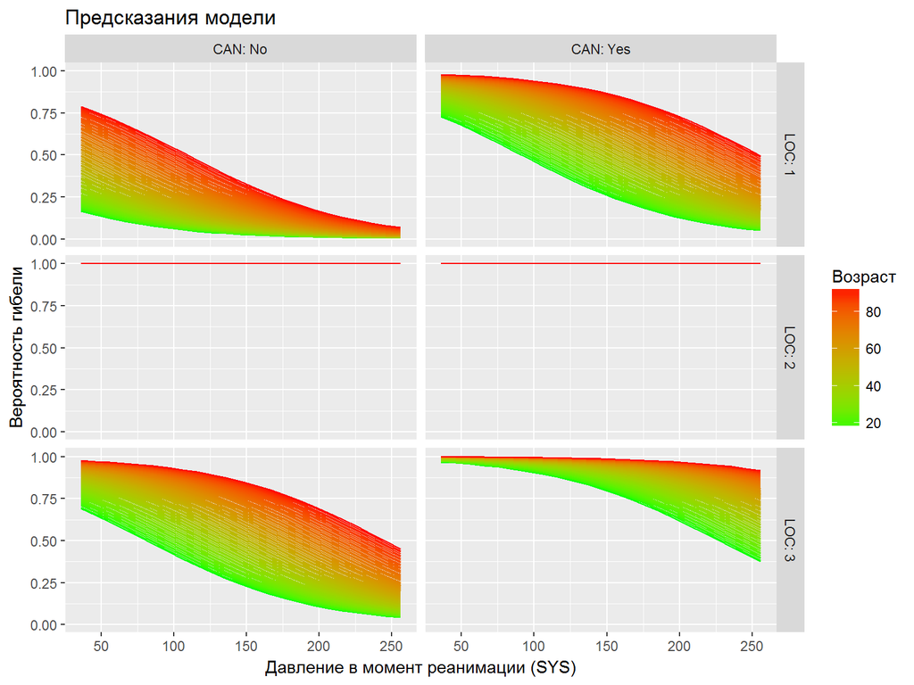

## Код для графика

```r
MyData = expand.grid(AGE = seq(min(surviv$AGE), max(surviv$AGE), 1),
                     CAN = levels(surviv$CAN),
                     SYS = seq(min(surviv$SYS), max(surviv$SYS), 10),
                     LOC =  levels(surviv$LOC),
                     TYP = "Emergency")

MyData$Predicted <- predict(M15, newdata = MyData, type = "response")



ggplot(MyData, aes(x=SYS, y = Predicted, color = AGE, group = AGE)) +
  geom_line() +
  facet_grid(LOC~ CAN, labeller = label_both) +
  scale_color_gradient(low = "green",  high = "red") +
  labs(label = list(x = "Давление в момент реанимации (SYS)", y = "Вероятность гибели", color = "Возраст", title = "Предсказания модели"))
```

## Summary

- При построении модели для бинарной зависимой перменной применяется логистическая регрессия.
- При построении такой модели 1 и 0 в перменной отклика заменяются логитами.
- Угловые коэффициенты подобранной логистической регрессии говорят о том, во сколько раз изменяется соотношение шансов события при увеличении предиктора на единицу.
- Оценить статистическую значимость модели можно с помощью анализа девиансы.

## Что почитать

- Кабаков Р.И. R в действии. Анализ и визуализация данных на языке R. М.: ДМК Пресс, 2014.
- Quinn G.P., Keough M.J. (2002) Experimental design and data analysis for biologists, pp. 92-98, 111-130
- Zuur, A.F. et al. 2009. Mixed effects models and extensions in ecology with R. - Statistics for biology and health. Springer, New York, NY.